# inventory_modelling

## Inventory Simulation Model

Consider the real-world scenario where many of us living in Interior Alaska must have our water delivered in trucks. The well-water isn’t very good, and the environment is too harsh for underground water distribution. So, on a regular basis we schedule trucks to refill our water tanks.

In this project, we want to estimate the cost of refilling the water station as well as the number of days when inventory is running low

```python
import matplotlib.pyplot as plt
import numpy as np
```

```python
def compute_avg_daily_cost(Q, T, d, s, N, qi):
    """
    Compute the average daily cost of a water station based on the given input parameters.

    Args:
        Q (float): Delivery quantity in gallons.
        T (int): Time between deliveries in days.
        d (float): Cost of delivery in dollars.
        s (float): Storage cost per gallon per day in dollars.
        N (int): Total simulation length in days.
        qi (func): func to calculate the distribution of demand


    Returns:
        float: average daily cost
    """

    I = 0 # current inventory
    C = 0 # total running cost
    cycles = N // T # number of delivery cycles if deliver every T days

    shortage_days = 0

    for cycle in range(cycles):
        # add delivery gallons to inventory
        I += Q
        # add cost of deliver to total Cost
        C += d

        # each day between inventory cycle
        for day in range(T):
            # demand for the day
            ri = qi()
            # substract demand from inventory
            if I >= ri:
                I -= ri
            else:
                I = 0
                shortage_days += 1
            # add storage cost to total cost
            C += I * s

    # remaining days not accounted for in the cycles
    for day in range(N%T):
        ri = qi()
        # substract demand from inventory
        if I >= ri:
            I -= ri
        else:
            I = 0
            shortage_days += 1
        # add storage cost to total cost
        C += I * s

    return C/N, shortage_days
```

### Model 1: Basic simulation model with constant demand

Simulate with constant demand:

- Expect the same costs and shortage days across simulation if all else constant.
- Expect 1 shortage days as we deliver 1000 gallons every 2 days for 365 days

```
In 365 days, We have 182 deliveries between every 2 days, and 1 days after the last delivery
```

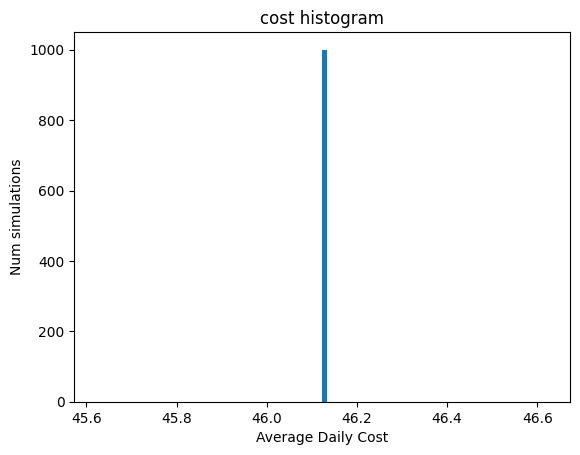

```python
def qi_constant(r=500):
    return r

Q = 1000 # Delivery quantity (gallons)
T = 2 # Time between deliveries (days)
N = 365 # Length of simulation (days)
d = 92.00 # Delivery cost (dollars per delivery)
s = 0.001 # Storage cost (dollars per gallon per day)
costs = []
simulations = 1000
num_shortage_days = []

print(f"In {N} days, We have {N//T} deliveries between every {T} days, and {N%T} days after the last delivery")

for i in range(simulations):
    cost, shortage_days = compute_avg_daily_cost(Q, T, d, s, N, qi_constant)
    num_shortage_days.append(shortage_days)
    costs.append(cost)

plt.hist(costs, bins = 100)
plt.title("cost histogram")
plt.ylabel("Num simulations")
plt.xlabel("Average Daily Cost")

plt.show()
```

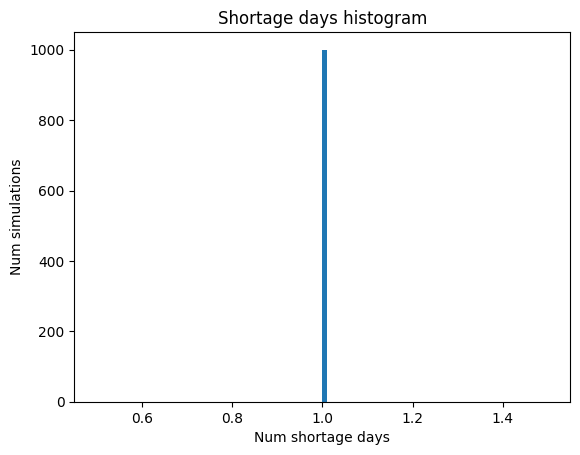

```python
plt.hist(num_shortage_days, bins = 100)
plt.title("Shortage days histogram")
plt.ylabel("Num simulations")
plt.xlabel("Num shortage days")
plt.show()
```

### Model 2: Historical daily demand rates

Simulate the inventory model with given demand history

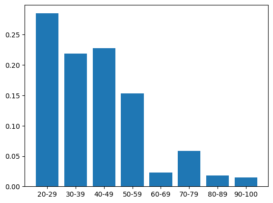

```python
gallons = np.array(["<20", "20-29", "30-39", "40-49", "50-59", "60-69", "70-79", "80-89", "90-100"])
demand = np.array([20, 30, 40, 50, 60, 70, 80, 90, 100])
days_occurrences = np.array([0, 208, 160, 166, 112, 17, 43, 13, 11])

# Calculate probability of each demand level
demand_probs = [days/sum(days_occurrences) for days in days_occurrences]
plt.bar(gallons[1:], demand_probs[1:])
plt.show()
```

```
[0.         0.28493151 0.50410959 0.73150685 0.88493151 0.90821918
 0.96712329 0.98493151 1.        ]
```

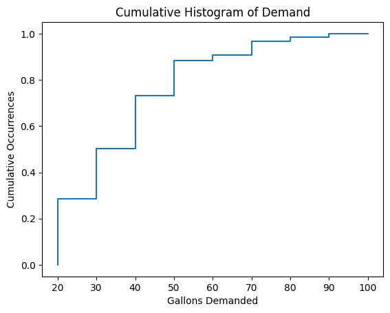

```python
# Buil a cumulative histogram of daily demand
# Compute cumulative sum of frequency counts
q = np.cumsum(demand_probs)
print(q)
# Plot histogram
plt.step(demand, q)
plt.xlabel('Gallons Demanded')
plt.ylabel('Cumulative Occurrences')
plt.title('Cumulative Histogram of Demand')
plt.show()
```

```python
# Represent the Cumulative hist with linear splines
# find m and b for the piecewise linear interpolations q = mx + b
m = np.zeros((demand.size - 1))
b = np.zeros((demand.size - 1))

for i in np.arange(demand.size - 1):
    m[i] = (q[i+1] - q[i]) / (demand[i+1] - demand[i])
    b[i] = q[i] - m[i] * demand[i]

# Inverse function x = (q - b)/m or x = q/m - b/m
minv = 1.0/m
binv = -b/m
```

```python
# Test the above Inverse function
# Compute inverses of linear splines to compute daily demand as a function of random number between [0,1]
import bisect
def qi_hist():
    """
    Return the demand based on historical data using inverse linear splines function
    """
    p = np.random.uniform()
    interval = bisect.bisect_right(q, p)
    random_demand = minv[interval - 1]*p + binv[interval - 1]
    return random_demand
```

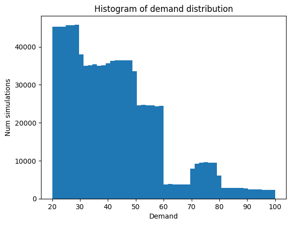

```python
# test above qi function
sims = 1000000

random_demands = np.zeros((sims))

for i in range(sims):
    random_demands[i] = qi_hist()

plt.hist(random_demands, bins = 50)
plt.title("Histogram of demand distribution")
plt.xlabel("Demand")
plt.ylabel("Num simulations")
plt.show()
```

```
In 365 days, We have 24 deliveries between every 15 days, and 5 days after the last delivery
```

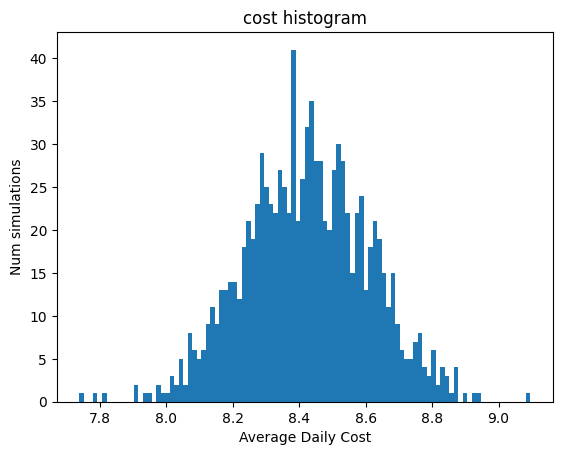

```python
Q = 800 # Delivery quantity (gallons)
T = 15 # Time between deliveries (days)
N = 365 # Length of simulation (days)
d = 92.00 # Delivery cost (dollars per delivery)
s = 0.001 # Storage cost (dollars per gallon per day)

costs = []
simulations = 1000
num_shortage_days = []

print(f"In {N} days, We have {N//T} deliveries between every {T} days, and {N%T} days after the last delivery")

for i in range(simulations):
    cost, shortage_days = compute_avg_daily_cost(Q, T, d, s, N, qi_hist)
    num_shortage_days.append(shortage_days)
    costs.append(cost)

plt.hist(costs, bins = 100)
plt.title("cost histogram")
plt.ylabel("Num simulations")
plt.xlabel("Average Daily Cost")

plt.show()
```

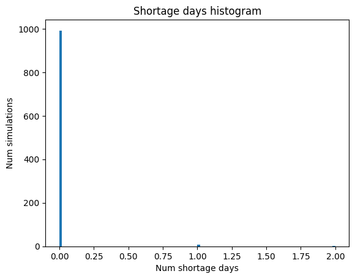

```python
plt.hist(num_shortage_days, bins = 100)
plt.title("Shortage days histogram")
plt.ylabel("Num simulations")
plt.xlabel("Num shortage days")
plt.show()
```

With T = 15 we have a few simulations with 1 or 2 days of zero water. We want to find the optimal Time between deliveries to avoid zero water day while keeping the cost down

```python
import pprint
deliveries_freq = [t for t in range(1, 30)]
simulations = 500
potential_t = {}

# for each time between deliveries, check the costs and shortage days across 500 simutions
for t in deliveries_freq:
    num_shortage_days = []
    costs = []
    for i in range(simulations):
        cost, shortage_days = compute_avg_daily_cost(Q, t, d, s, N, qi_hist)
        num_shortage_days.append(shortage_days)
        costs.append(cost)

    # Only keep the time that has no Zero Water Days, calc the average costs across 500 simutions
    if sum(num_shortage_days) == 0:
        potential_t[t] = sum(costs)/simulations
```

```python
pprint.pprint(potential_t)
```

```
{1: 230.66080092068827,
 2: 111.5269984325556,
 3: 71.8023054752356,
 4: 52.092069719328165,
 5: 40.23609634534847,
 6: 32.08486615392224,
 7: 26.627170240945684,
 8: 22.230285525045417,
 9: 18.960728150565345,
 10: 16.316133335550752,
 11: 14.232266657578185,
 12: 12.367344431486442,
 13: 10.948544561136849,
 14: 9.628021573839478}
```

We can see that across 500 simulations, if we deliver every 14 days we will have No Zero Water Days, and the lowest cost. The average daily cost follows a normal distribution

```
In 365 days, We have 26 deliveries between every 14 days, and 1 days after the last delivery
```

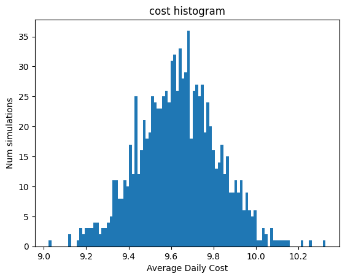

```python
Q = 800 # Delivery quantity (gallons)
T = 14 # Time between deliveries (days)
N = 365 # Length of simulation (days)
d = 92.00 # Delivery cost (dollars per delivery)
s = 0.001 # Storage cost (dollars per gallon per day)

costs = []
simulations = 1000
num_shortage_days = []

print(f"In {N} days, We have {N//T} deliveries between every {T} days, and {N%T} days after the last delivery")

for i in range(simulations):
    cost, shortage_days = compute_avg_daily_cost(Q, T, d, s, N, qi_hist)
    num_shortage_days.append(shortage_days)
    costs.append(cost)

plt.hist(costs, bins = 100)
plt.title("cost histogram")
plt.ylabel("Num simulations")
plt.xlabel("Average Daily Cost")

plt.show()
```

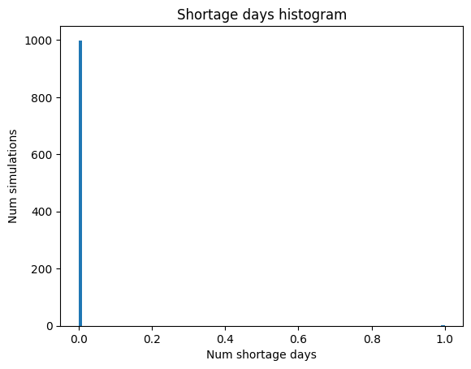

```python
plt.hist(num_shortage_days, bins = 100)
plt.title("Shortage days histogram")
plt.ylabel("Num simulations")
plt.xlabel("Num shortage days")
plt.show()
```